# Problem set 8: tree-based methods and support vector machines

Shen Han

Mar 6, 2017

```r
library(tidyverse)
library(knitr)
library(forcats)
library(gridExtra)
library(grid)
library(broom)
library(modelr)
library(tree)
library(randomForest)
library(stringr)
library(ISLR)
library(pROC)
library(gbm)
```

```r
library(ggdendro)
library(e1071)

options(digits = 3)
```

```r
biden <- read_csv("data/biden.csv") %>%
  mutate_each(funs(as.factor(.)), female, dem, rep)
mental_health <- read_csv("data/mental_health.csv") %>%
  mutate_each(funs(as.factor(.)), vote96, black, female, married) %>%
  na.omit
simpson <- read_csv("data/simpson.csv") %>%
  mutate_each(funs(as.factor(.)), guilt, dem, rep, ind, female, black, hispanic, educ, income)
```

# Part 1: Sexy Joe Biden (redux times two)

## 1. Split the data into a training set (70%) and a validation set (30%).

```r
set.seed(1234)

biden_split <- resample_partition(biden, c(test = 0.3, train = 0.7))
```

## 2. Fit a decision tree to the training data with default options, with biden as the response variable and the other variables as predictors. Plot the tree and interpret the results. What is the test MSE?

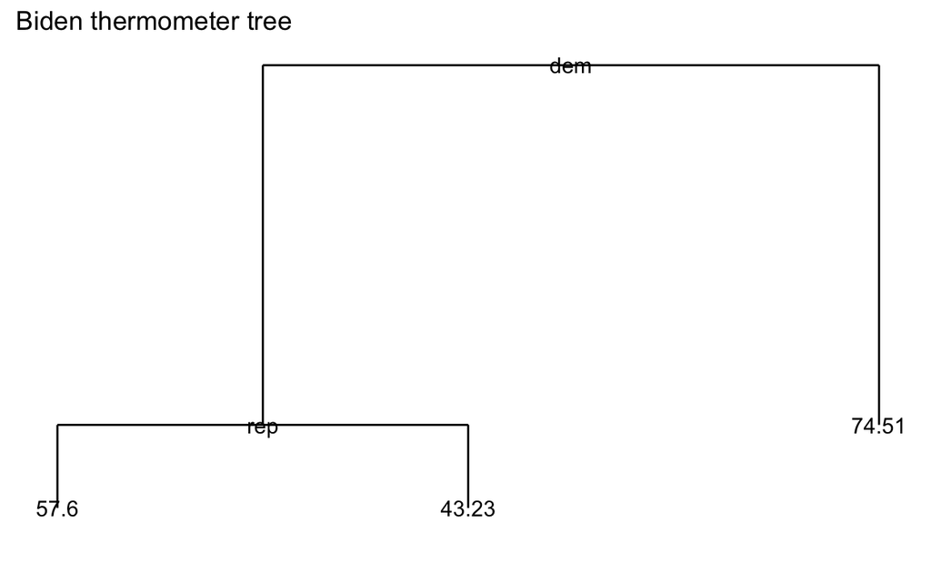

```r
set.seed(1234)

biden_tree_default <- tree(biden ~ female + age + dem + rep + educ, data = biden_split$train)

tree_data <- dendro_data(biden_tree_default)

ggplot(segment(tree_data)) +
  geom_segment(aes(x = x, y = y, xend = xend, yend = yend)) +
  geom_text(data = label(tree_data), aes(x = x, y = y, label = label)) +
  geom_text(data = leaf_label(tree_data), aes(x = x, y = y, label = label)) +
  theme_dendro() +
  labs(title = "Biden thermometer tree")
```

```r
mse <- function(model, data) {
  x <- modelr:::residuals(model, data)
  mean(x ^ 2, na.rm = TRUE)
}


biden_tree_default_testmse <- mse(biden_tree_default, biden_split$test)
biden_tree_default_testmse
```

```
## [1] 406
```

The tree graph shows:

If the respondent is a Democrat, then the estimate value of her Biden feeling score is 74.51.  
If the respondent is a Republican, then the estimate value of her Biden feeling score is 43.23. If the respondent is neither a Republican nor a Democrat, then the estimate value of her Biden feeling score is 57.6.

The test MSE is 406.417.

## 3. Fit another tree to the training data with control options. Use cross-validation to determine the optimal level of tree complexity, plot the optimal tree, and interpret the results. Does pruning the tree improve the test MSE?

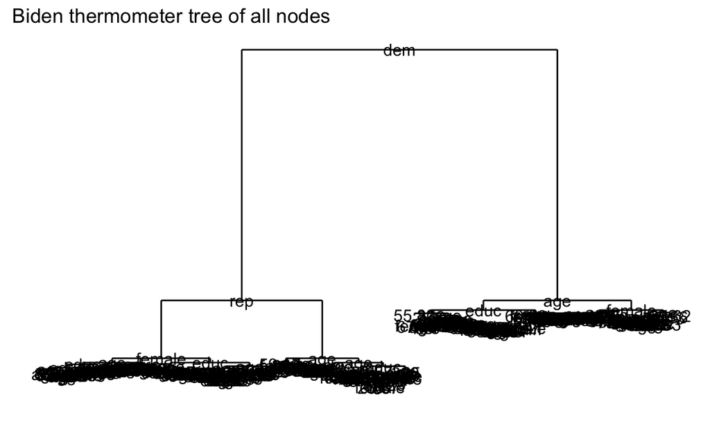

```r
set.seed(1234)

biden_tree_option <- tree(biden ~ female + age + dem + rep + educ, data = biden_split$train, control = tree.control(nobs = nrow(biden_split$train), mindev = 0))

tree_data <- dendro_data(biden_tree_option)

ggplot(segment(tree_data)) +
  geom_segment(aes(x = x, y = y, xend = xend, yend = yend)) +
  geom_text(data = label(tree_data), aes(x = x, y = y, label = label)) +
  geom_text(data = leaf_label(tree_data), aes(x = x, y = y, label = label)) +
  theme_dendro() +
  labs(title = "Biden thermometer tree of all nodes")
```

```r
biden_tree_control_testmse <- mse(biden_tree_option, biden_split$test)
biden_tree_control_testmse
```

```
## [1] 481
```

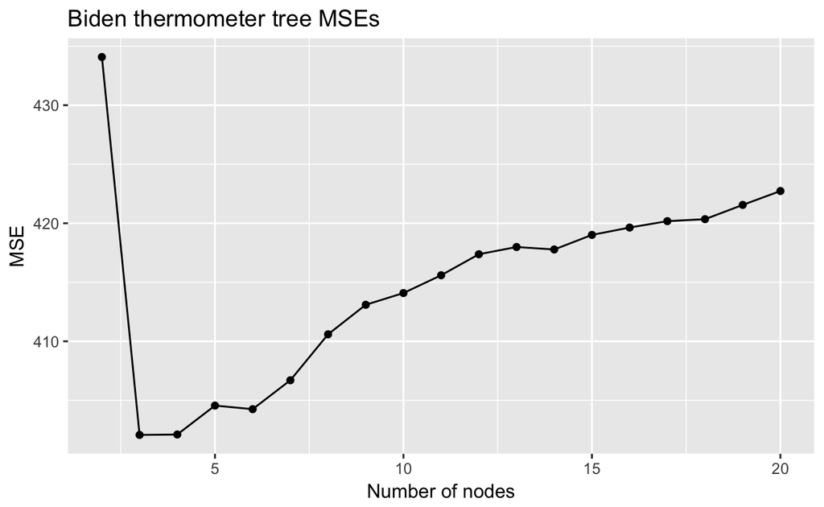

```r
biden_cv <- crossv_kfold(biden, k = 10) %>%
  mutate(tree = map(train, ~ tree(biden ~ female + age + dem + rep + educ, data = ., control = tree.control(nobs = nrow(biden), mindev = 0))))


biden_cv <- expand.grid(biden_cv$.id, 2:20) %>%
  as_tibble() %>%
  mutate(Var2 = as.numeric(Var2)) %>%
  rename(.id = Var1,
         k = Var2) %>%
  left_join(biden_cv) %>%
  mutate(prune = map2(tree, k, ~ prune.tree(.x, best = .y)),
         mse = map2_dbl(prune, test, mse))
biden_cv %>%
  select(k, mse) %>%
  group_by(k) %>%
  summarize(test_mse = mean(mse),
            sd = sd(mse, na.rm = TRUE)) %>%
  ggplot(aes(k, test_mse)) +
  geom_point() +
  geom_line() +
  labs(title = "Biden thermometer tree MSEs",
       x = "Number of nodes",
       y = "MSE")
```

```r
biden_cv %>%
  select(k, mse) %>%
  group_by(k) %>%
  summarize(test_mse = mean(mse),
            sd = sd(mse, na.rm = TRUE))
```

```
## # A tibble: 19 × 3
##        k test_mse    sd
##    <dbl>    <dbl> <dbl>
## 1      2      434  28.8
## 2      3      402  38.5
## 3      4      402  39.4
## 4      5      405  39.6
## 5      6      404  38.9
## 6      7      407  41.3
## 7      8      411  40.4
## 8      9      413  38.3
## 9     10      414  37.3
## 10    11      416  35.9
## 11    12      417  34.2
## 12    13      418  34.7
## 13    14      418  34.8
## 14    15      419  34.8
## 15    16      420  33.2
## 16    17      420  32.6
## 17    18      420  33.8
## 18    19      422  33.2
## 19    20      423  32.2
```

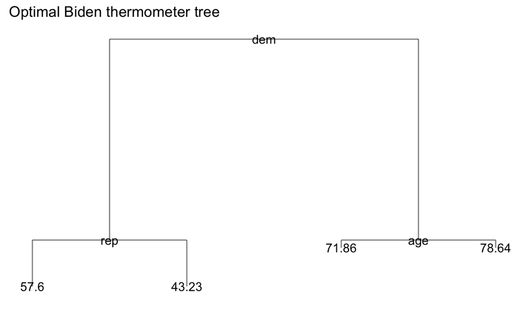

```r
mod <- prune.tree(biden_tree_option, best = 4)

tree_data <- dendro_data(mod)
ggplot(segment(tree_data)) +
  geom_segment(aes(x = x, y = y, xend = xend, yend = yend),
               alpha = 0.5) +
  geom_text(data = label(tree_data),
            aes(x = x, y = y, label = label)) +
  geom_text(data = leaf_label(tree_data),
            aes(x = x, y = y, label = label)) +
  theme_dendro() +
  labs(title = "Optimal Biden thermometer tree")
```

The optimal tree shows:

If the respondent is a Democrat, then look at her age: If she is elder than 53.5 years old, then the estimate value of her Biden feeling score is 78.64, otherwise is 71.86.

If the respondent is a Republican, then the estimate value of her Biden feeling score is 43.23.

If the respondent is neither a Republican nor a Democrat, then the estimate value of her Biden feeling score is 57.6.

The pruned tree has an MSE at 402.1, which is lower than the original 481. It means the full node model may overfit the data.

## 4. Use the bagging approach to analyze this data. What test MSE do you obtain? Obtain variable importance measures and interpret the results.

```r
set.seed(1234)

biden_bag <- randomForest(biden ~ ., data = biden, mtry = 5, ntree = 500)
biden_bag
```

```
##
## Call:
##  randomForest(formula = biden ~ ., data = biden, mtry = 5, ntree = 500)
##                Type of random forest: regression
##                      Number of trees: 500
## No. of variables tried at each split: 5
##
##           Mean of squared residuals: 495
##                     % Var explained: 10.1
```

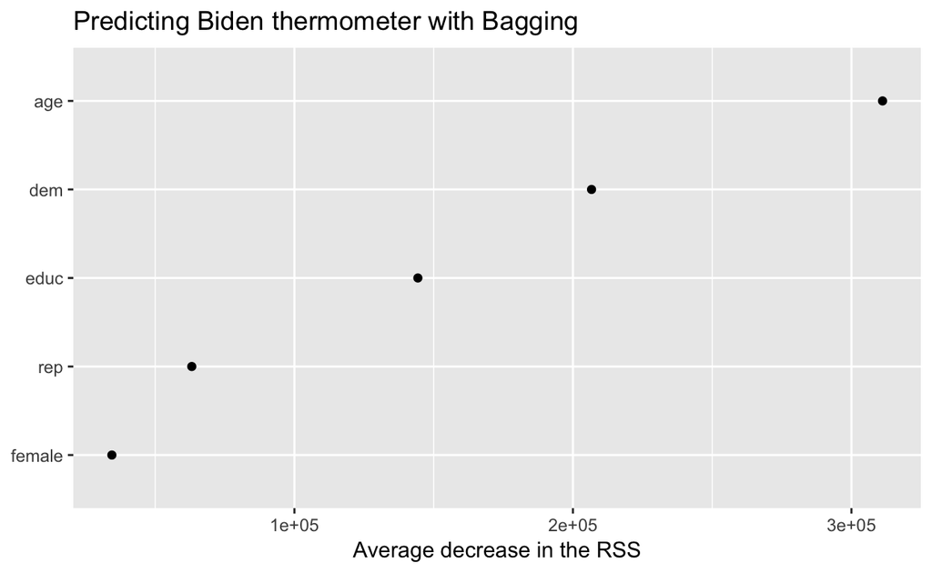

```r
data_frame(var = rownames(importance(biden_bag)),
           MeanDecreaseRSS = importance(biden_bag)[,1]) %>%
  mutate(var = fct_reorder(var, MeanDecreaseRSS, fun = median)) %>%
  ggplot(aes(var, MeanDecreaseRSS)) +
  geom_point() +
  coord_flip() +
  labs(title = "Predicting Biden thermometer with Bagging",
       x = NULL,
       y = "Average decrease in the RSS")
```

Test MSE from bagging is 495, which probably indicates overfitting.

From the variable importance measures we can see that age is the most important variable, then Democrat indicator and education level. Republican indicator and female indicator is less important.

## 5. Use the random forest approach to analyze this data. What test MSE do you obtain? Obtain variable importance measures and interpret the results. Describe the effect of m, the number of variables considered at each split, on the error rate obtained.

```r
set.seed(1234)

biden_rf <- randomForest(biden ~ ., data = biden, ntree = 500)
biden_rf
```

```
##
## Call:
##  randomForest(formula = biden ~ ., data = biden, ntree = 500)
##                Type of random forest: regression
##                      Number of trees: 500
## No. of variables tried at each split: 1
##
##           Mean of squared residuals: 408
##                     % Var explained: 25.9
```

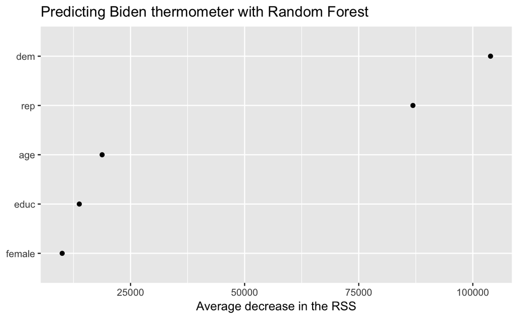

```r
data_frame(var = rownames(importance(biden_rf)),
           MeanDecreaseRSS = importance(biden_rf)[,1]) %>%
  mutate(var = fct_reorder(var, MeanDecreaseRSS, fun = median)) %>%
  ggplot(aes(var, MeanDecreaseRSS)) +
  geom_point() +
  coord_flip() +
  labs(title = "Predicting Biden thermometer with Random Forest",
       x = NULL,
       y = "Average decrease in the RSS")
```

The test MSE from Random Forest is 408, which is lower than the previous one and indicates a stabler result.

From the variable importance measures we can see that Democrat and Republican indicators are the most important variables, which is very intuitive. Age, education level and female indicator are less important.

`m` limits the predictors can be chosen by the model in each node.

## 6. Use the boosting approach to analyze the data. What test MSE do you obtain? How does the value of the shrinkage parameter λ influence the test MSE?

```r
set.seed(1234)

biden_boost <- gbm(biden ~ ., data = biden_split$train, n.trees = 10000, interaction.depth = 1)
```

```
## Distribution not specified, assuming gaussian ...
```

```r
yhat_boost = predict(biden_boost, newdata = biden_split$test, n.trees = 10000)

mean((yhat_boost - biden[biden_split$test[2]$idx, ]$biden)^2)
```

```
## [1] 400
```

```r
mses <- numeric(4)
shrinkages <- numeric(4)
for (s in 1:4){
  shrinkages[s] <- 10^(-s)
  biden_boost <- gbm(biden ~ ., data = biden_split$train, n.trees = 10000, interaction.depth = 1, shrinkage = shrinkages[s])
  yhat_boost = predict(biden_boost, newdata = biden_split$test, n.trees = 10000)
  mses[s] <- mean((yhat_boost - biden[biden_split$test[2]$idx, ]$biden)^2)
}
```

```
## Distribution not specified, assuming gaussian ...
## Distribution not specified, assuming gaussian ...
## Distribution not specified, assuming gaussian ...
## Distribution not specified, assuming gaussian ...
```

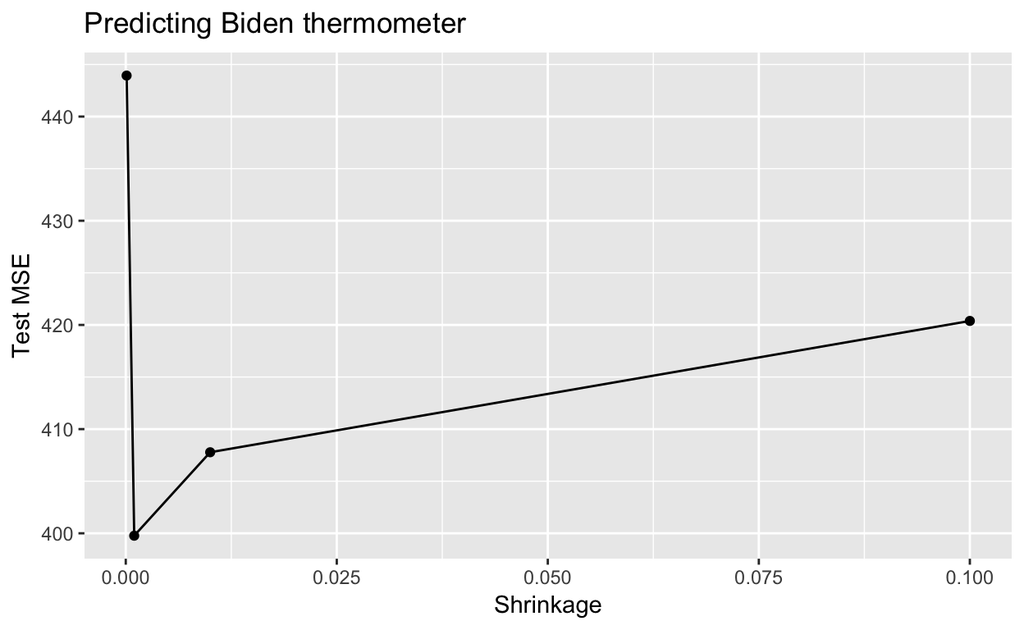

```r
data_frame(mse = mses, shrinkage = shrinkages) %>%
  ggplot(aes(shrinkage, mse)) +
  geom_point() +
  geom_line() +
  labs(title = "Predicting Biden thermometer",
       x = "Shrinkage",
       y = "Test MSE")
```

The test MSE from boosting approach is 399.5.

The test MSE firstly goes down in (0, 0.001], then goes up gradually, which indicates $\lambda = 0.001$ may be the best choice.

# Part 2: Modeling voter turnout

## 1. Use cross-validation techniques and standard measures of model fit to compare and evaluate at least five tree-based models of voter turnout. Select the best model and interpret the results using whatever methods you see fit.

```r
set.seed(1234)
mental_health_split <- resample_partition(mental_health, p = c("test" = .3, "train" = .7))
```

### Model 1

```r
mental_health_tree <- tree(vote96 ~ educ + mhealth_sum, data = as_tibble(mental_health_split$train))
mental_health_tree
```

```
## node), split, n, deviance, yval, (yprob)
##       * denotes terminal node
##
## 1) root 816 1000 1 ( 0 1 )
##   2) mhealth_sum < 4.5 648  700 1 ( 0 1 )
##     4) educ < 15.5 449  600 1 ( 0 1 ) *
##     5) educ > 15.5 199  100 1 ( 0 1 ) *
##   3) mhealth_sum > 4.5 168  200 0 ( 1 0 ) *
```

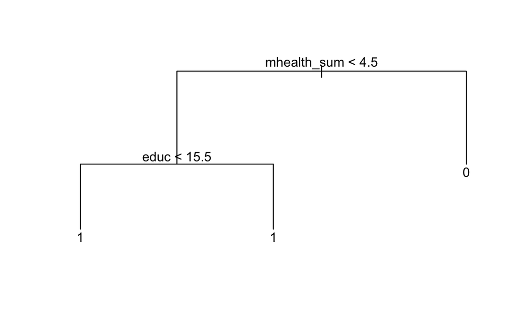

```r
plot(mental_health_tree)
text(mental_health_tree, pretty = 0)
```

```r
fitted <- predict(mental_health_tree, as_tibble(mental_health_split$test), type = "class")
tree_err <- mean(as_tibble(mental_health_split$test)$vote96 != fitted)
tree_err
```

```
## [1] 0.335
```

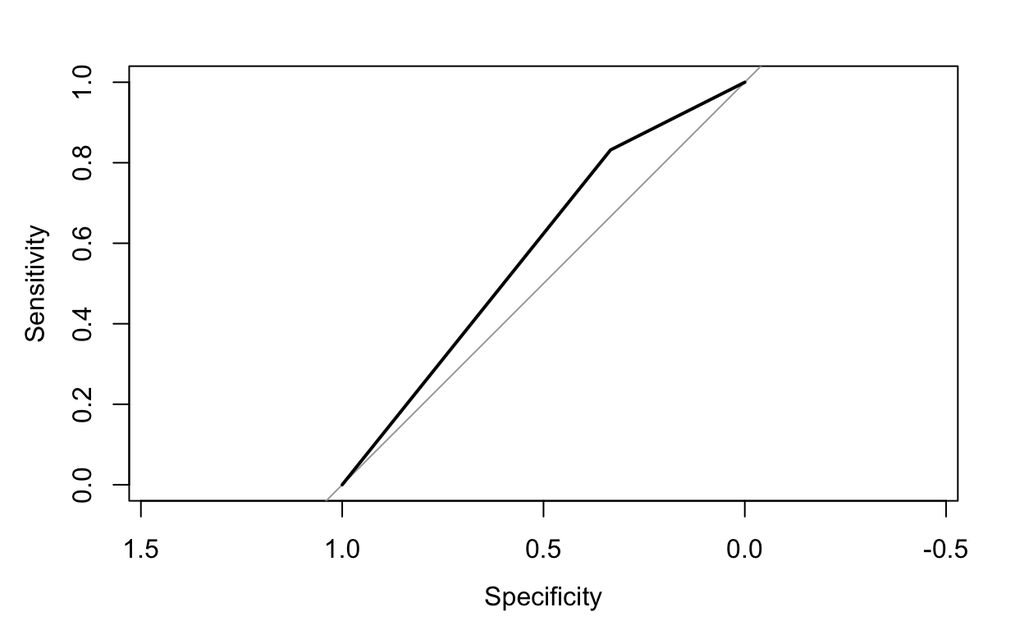

```r
roc_tree2 <- roc(as.numeric(as_tibble(mental_health_split$test)$vote96), as.numeric(fitted))
plot(roc_tree2)
```

```r
auc(roc_tree2)
```

```
## Area under the curve: 0.583
```

### Model 2

```r
fitted <- predict(mental_health_tree, as_tibble(mental_health_split$test), type = "class")
tree_err <- mean(as_tibble(mental_health_split$test)$vote96 != fitted)
tree_err
```

```
## [1] 0.335
```

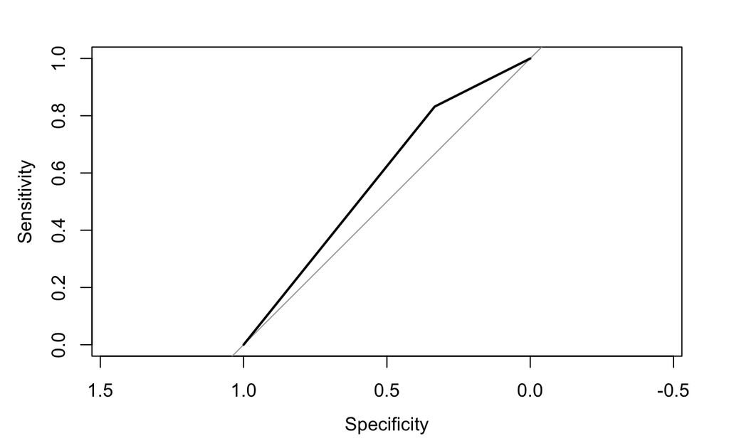

```r
roc_tree1 <- roc(as.numeric(as_tibble(mental_health_split$test)$vote96), as.numeric(fitted))
plot(roc_tree1)
```

```r
auc(roc_tree1)
```

```
## Area under the curve: 0.583
```

### Model 3

```r
mental_health_tree <- tree(vote96 ~ educ + mhealth_sum + age, data = as_tibble(mental_health_split$train))
mental_health_tree
```

```
## node), split, n, deviance, yval, (yprob)
##       * denotes terminal node
##
##  1) root 816 1000 1 ( 0 1 )
##    2) mhealth_sum < 4.5 648  700 1 ( 0 1 )
##      4) age < 44.5 346  500 1 ( 0 1 )
##        8) educ < 14.5 214  300 1 ( 0 1 ) *
##        9) educ > 14.5 132  100 1 ( 0 1 )
##         18) mhealth_sum < 0.5 39    9 1 ( 0 1 ) *
##         19) mhealth_sum > 0.5 93  100 1 ( 0 1 ) *
##      5) age > 44.5 302  200 1 ( 0 1 )
##       10) educ < 15.5 217  200 1 ( 0 1 ) *
##       11) educ > 15.5 85   20 1 ( 0 1 ) *
##    3) mhealth_sum > 4.5 168  200 0 ( 1 0 )
##      6) age < 30.5 45   50 0 ( 1 0 ) *
##      7) age > 30.5 123  200 1 ( 0 1 ) *
```

```r
plot(mental_health_tree)
text(mental_health_tree, pretty = 0)
```

[output not shown]

```r
fitted <- predict(mental_health_tree, as_tibble(mental_health_split$test), type = "class")
tree_err <- mean(as_tibble(mental_health_split$test)$vote96 != fitted)
tree_err
```

```
## [1] 0.304
```

```r
roc_tree3 <- roc(as.numeric(as_tibble(mental_health_split$test)$vote96), as.numeric(fitted))
plot(roc_tree3)
```

[output not shown]

```r
auc(roc_tree3)
```

```
## Area under the curve: 0.56
```

### Model 4

```r
mental_health_tree <- tree(vote96 ~ educ + mhealth_sum + age + inc10, data = as_tibble(mental_health_split$train))
mental_health_tree
```

```
## node), split, n, deviance, yval, (yprob)
##       * denotes terminal node
##
##  1) root 816 1000 1 ( 0 1 )
##    2) mhealth_sum < 4.5 648  700 1 ( 0 1 )
##      4) age < 44.5 346  500 1 ( 0 1 )
##        8) educ < 14.5 214  300 1 ( 0 1 ) *
##        9) educ > 14.5 132  100 1 ( 0 1 )
##         18) mhealth_sum < 0.5 39    9 1 ( 0 1 ) *
##         19) mhealth_sum > 0.5 93  100 1 ( 0 1 ) *
##      5) age > 44.5 302  200 1 ( 0 1 )
##       10) educ < 15.5 217  200 1 ( 0 1 ) *
##       11) educ > 15.5 85   20 1 ( 0 1 ) *
##    3) mhealth_sum > 4.5 168  200 0 ( 1 0 )
##      6) age < 30.5 45   50 0 ( 1 0 ) *
##      7) age > 30.5 123  200 1 ( 0 1 ) *
```

```r
plot(mental_health_tree)
text(mental_health_tree, pretty = 0)
```

[output not shown]

```r
fitted <- predict(mental_health_tree, as_tibble(mental_health_split$test), type = "class")
tree_err <- mean(as_tibble(mental_health_split$test)$vote96 != fitted)
tree_err
```

```
## [1] 0.304
```

```r
roc_tree4 <- roc(as.numeric(as_tibble(mental_health_split$test)$vote96), as.numeric(fitted))
plot(roc_tree4)
```

[output not shown]

```r
auc(roc_tree4)
```

```
## Area under the curve: 0.56
```

### Model 5

```r
mental_health_tree <- tree(vote96 ~ ., data = as_tibble(mental_health_split$train))
mental_health_tree
```

```
## node), split, n, deviance, yval, (yprob)
##       * denotes terminal node
##
##  1) root 816 1000 1 ( 0 1 )
##    2) mhealth_sum < 4.5 648  700 1 ( 0 1 )
##      4) age < 44.5 346  500 1 ( 0 1 )
##        8) educ < 14.5 214  300 1 ( 0 1 ) *
##        9) educ > 14.5 132  100 1 ( 0 1 )
##         18) mhealth_sum < 0.5 39    9 1 ( 0 1 ) *
##         19) mhealth_sum > 0.5 93  100 1 ( 0 1 ) *
##      5) age > 44.5 302  200 1 ( 0 1 )
##       10) educ < 15.5 217  200 1 ( 0 1 ) *
##       11) educ > 15.5 85   20 1 ( 0 1 ) *
##    3) mhealth_sum > 4.5 168  200 0 ( 1 0 )
##      6) age < 30.5 45   50 0 ( 1 0 ) *
##      7) age > 30.5 123  200 1 ( 0 1 ) *
```

```r
plot(mental_health_tree)
text(mental_health_tree, pretty = 0)
```

[output not shown]

```r
fitted <- predict(mental_health_tree, as_tibble(mental_health_split$test), type = "class")
tree_err <- mean(as_tibble(mental_health_split$test)$vote96 != fitted)
tree_err
```

```
## [1] 0.304
```

```r
roc_tree5 <- roc(as.numeric(as_tibble(mental_health_split$test)$vote96), as.numeric(fitted))
plot(roc_tree5)
```

[output not shown]

```r
auc(roc_tree5)
```

```
## Area under the curve: 0.56
```

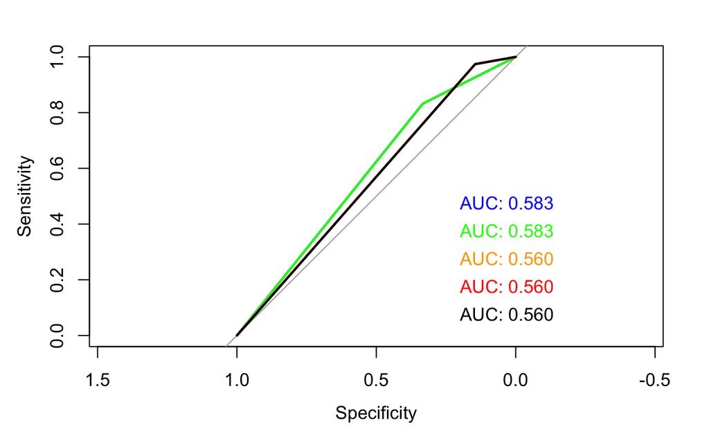

```r
plot(roc_tree1, print.auc = TRUE, col = "blue", print.auc.x = .2)
plot(roc_tree2, print.auc = TRUE, col = "green", print.auc.x = .2, print.auc.y = .4, add = TRUE)
plot(roc_tree3, print.auc = TRUE, col = "orange", print.auc.x = .2, print.auc.y = .3, add = TRUE)
plot(roc_tree4, print.auc = TRUE, col = "red", print.auc.x = .2, print.auc.y = .2, add = TRUE)
plot(roc_tree5, print.auc = TRUE, col = "black", print.auc.x = .2, print.auc.y = .1, add = TRUE)
```

For me, model 3 seems most resonable, since it yields the same result with Model 5 and 5 without adding new predictors, while the AUC of the above models are about the same.

## 2. Use cross-validation techniques and standard measures of model fit to compare and evaluate at least five SVM models of voter turnout. Select the best model and interpret the results using whatever methods you see fit.

### Model 1

```r
mental_health_lin_tune <- tune(svm, vote96 ~ educ + age + mhealth_sum, data = as_tibble(mental_health_split$train),
                    kernel = "linear",
                    range = list(cost = c(.001, .01, .1, 1, 5, 10, 100)))

mental_health_lin <- mental_health_lin_tune$best.model
summary(mental_health_lin)
```

```
##
## Call:
## best.tune(method = svm, train.x = vote96 ~ educ + age + mhealth_sum,
##     data = as_tibble(mental_health_split$train), ranges = list(cost = c(0.001,
##         0.01, 0.1, 1, 5, 10, 100)), kernel = "linear")
##
##
## Parameters:
##    SVM-Type:  C-classification
##  SVM-Kernel:  linear
##        cost:  1
##       gamma:  0.333
##
## Number of Support Vectors:  511
##
##  ( 255 256 )
##
##
## Number of Classes:  2
##
## Levels:
##  0 1
```

```r
fitted <- predict(mental_health_lin, as_tibble(mental_health_split$test), decision.values = TRUE) %>%
  attributes


roc_line <- roc(as_tibble(mental_health_split$test)$vote96, fitted$decision.values)
auc(roc_line)
```

```
## Area under the curve: 0.737
```

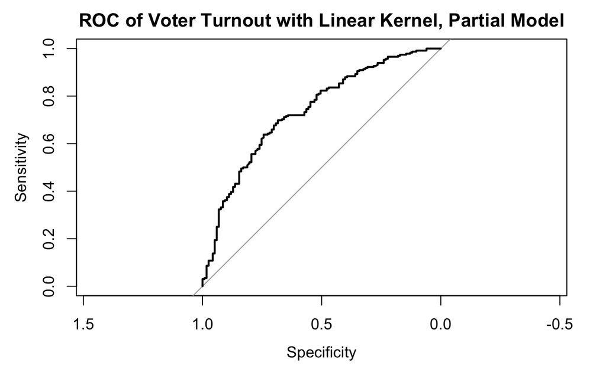

```r
plot(roc_line, main = "ROC of Voter Turnout with Linear Kernel, Partial Model")
```

### Model 2

```r
mental_health_lin_all <- tune(svm, vote96 ~ ., data = as_tibble(mental_health_split$train),
                    kernel = "linear",
                    range = list(cost = c(.001, .01, .1, 1, 5, 10, 100)))

mental_health_lall <- mental_health_lin_all$best.model
summary(mental_health_lall)
```

```
##
## Call:
## best.tune(method = svm, train.x = vote96 ~ ., data = as_tibble(mental_health_split$train),
##     ranges = list(cost = c(0.001, 0.01, 0.1, 1, 5, 10, 100)),
##     kernel = "linear")
##
##
## Parameters:
##    SVM-Type:  C-classification
##  SVM-Kernel:  linear
##        cost:  10
##       gamma:  0.125
##
## Number of Support Vectors:  507
##
##  ( 255 252 )
##
##
## Number of Classes:  2
##
## Levels:
##  0 1
```

```r
fitted <- predict(mental_health_lall, as_tibble(mental_health_split$test), decision.values = TRUE) %>%
  attributes


roc_line_all <- roc(as_tibble(mental_health_split$test)$vote96, fitted$decision.values)
auc(roc_line_all)
```

```
## Area under the curve: 0.746
```

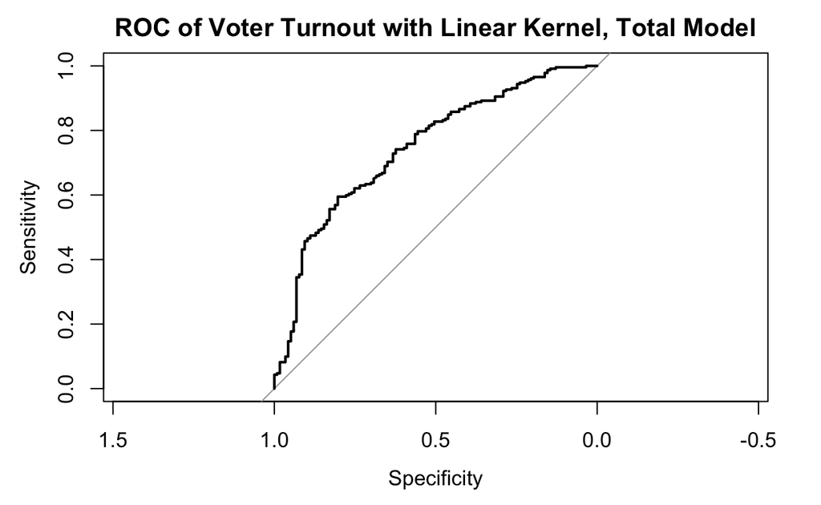

```r
plot(roc_line_all, main = "ROC of Voter Turnout with Linear Kernel, Total Model")
```

## Model 3

```r
mental_health_poly_tune <- tune(svm, vote96 ~ age + educ + mhealth_sum, data = as_tibble(mental_health_split$train),
                    kernel = "polynomial",
                    range = list(cost = c(.001, .01, .1, 1, 5, 10, 100)))

mental_health_poly <- mental_health_poly_tune$best.model
summary(mental_health_poly)
```

```
##
## Call:
## best.tune(method = svm, train.x = vote96 ~ age + educ + mhealth_sum,
##     data = as_tibble(mental_health_split$train), ranges = list(cost = c(0.001,
##         0.01, 0.1, 1, 5, 10, 100)), kernel = "polynomial")
##
##
## Parameters:
##    SVM-Type:  C-classification
##  SVM-Kernel:  polynomial
##        cost:  10
##      degree:  3
##       gamma:  0.333
##      coef.0:  0
##
## Number of Support Vectors:  494
##
##  ( 248 246 )
##
##
## Number of Classes:  2
##
## Levels:
##  0 1
```

```r
fitted <- predict(mental_health_poly, as_tibble(mental_health_split$test), decision.values = TRUE) %>%
  attributes

roc_poly <- roc(as_tibble(mental_health_split$test)$vote96, fitted$decision.values)
```

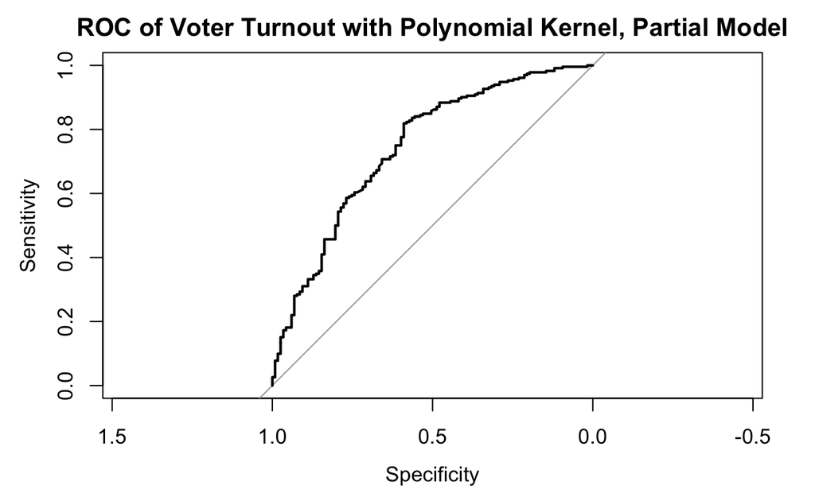

```r
plot(roc_poly, main = "ROC of Voter Turnout with Polynomial Kernel, Partial Model")
```

## Model 4

```r
mental_health_poly_all <- tune(svm, vote96 ~ ., data = as_tibble(mental_health_split$train),
                    kernel = "polynomial",
                    range = list(cost = c(.001, .01, .1, 1, 5, 10, 100)))

mental_health_poly <- mental_health_poly_all$best.model
summary(mental_health_poly)
```

```
##
## Call:
## best.tune(method = svm, train.x = vote96 ~ ., data = as_tibble(mental_health_split$train),
##     ranges = list(cost = c(0.001, 0.01, 0.1, 1, 5, 10, 100)),
##     kernel = "polynomial")
##
##
## Parameters:
##    SVM-Type:  C-classification
##  SVM-Kernel:  polynomial
##        cost:  5
##      degree:  3
##       gamma:  0.125
##      coef.0:  0
##
## Number of Support Vectors:  495
##
##  ( 258 237 )
##
##
## Number of Classes:  2
##
## Levels:
##  0 1
```

```r
fitted <- predict(mental_health_poly, as_tibble(mental_health_split$test), decision.values = TRUE) %>%
  attributes

roc_poly_all <- roc(as_tibble(mental_health_split$test)$vote96, fitted$decision.values)
```

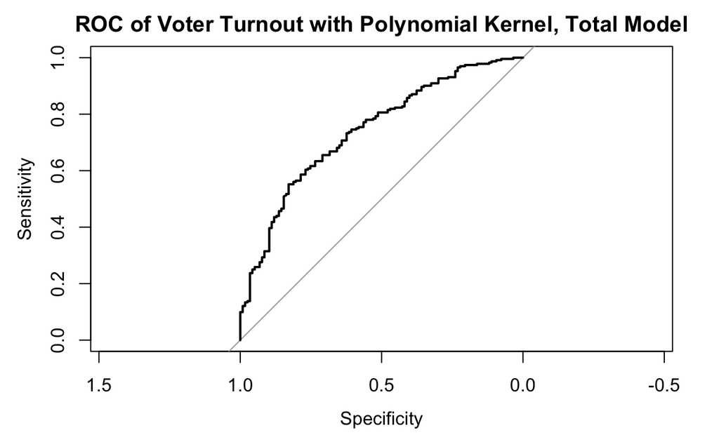

```r
plot(roc_poly_all, main = "ROC of Voter Turnout with Polynomial Kernel, Total Model")
```

## Model 5

```r
mental_health_rad_tune <- tune(svm, vote96 ~ ., data = as_tibble(mental_health_split$train),
                    kernel = "radial",
                    range = list(cost = c(.001, .01, .1, 1, 5, 10, 100)))

mental_health_rad <- mental_health_rad_tune$best.model
summary(mental_health_rad)
```

```
##
## Call:
## best.tune(method = svm, train.x = vote96 ~ ., data = as_tibble(mental_health_split$train),
##     ranges = list(cost = c(0.001, 0.01, 0.1, 1, 5, 10, 100)),
##     kernel = "radial")
##
##
## Parameters:
##    SVM-Type:  C-classification
##  SVM-Kernel:  radial
##        cost:  5
##       gamma:  0.125
##
## Number of Support Vectors:  494
##
##  ( 258 236 )
##
##
## Number of Classes:  2
##
## Levels:
##  0 1
```

```r
fitted <- predict(mental_health_rad, as_tibble(mental_health_split$test), decision.values = TRUE) %>%
  attributes

roc_rad <- roc(as_tibble(mental_health_split$test)$vote96, fitted$decision.values)
```

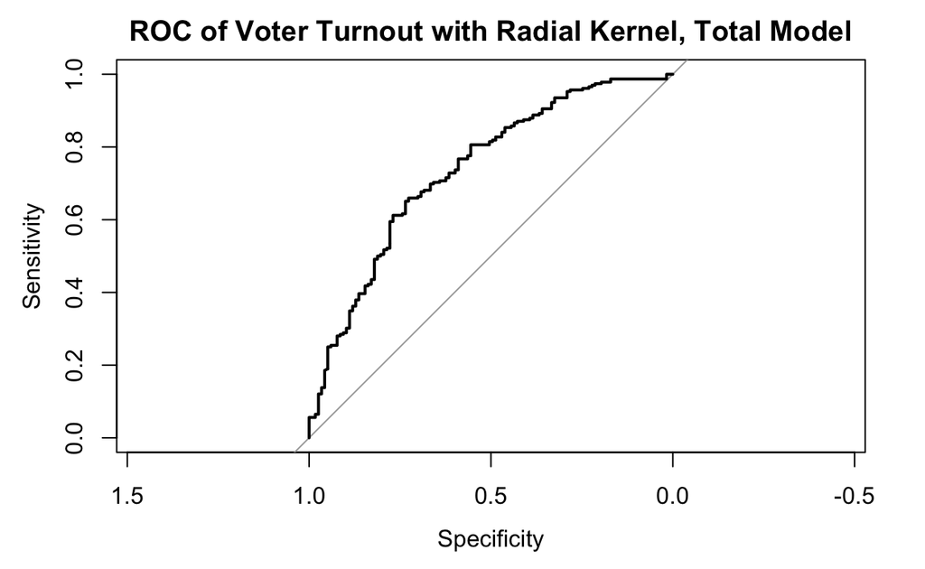

```r
plot(roc_rad, main= "ROC of Voter Turnout with Radial Kernel, Total Model")
```

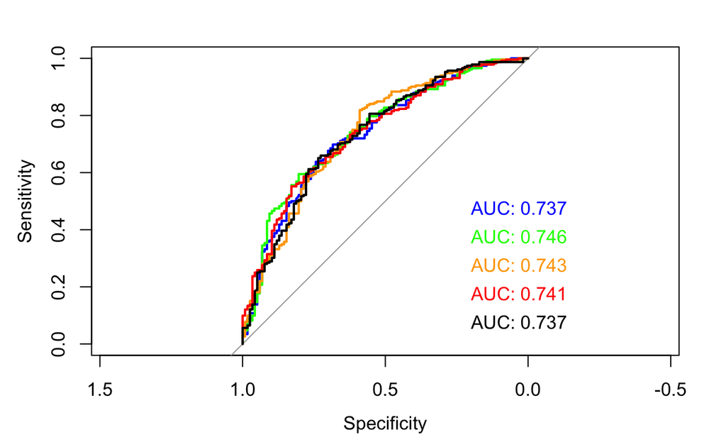

```r
plot(roc_line, print.auc = TRUE, col = "blue", print.auc.x = .2)
plot(roc_line_all, print.auc = TRUE, col = "green", print.auc.x = .2, print.auc.y = .4, add = TRUE)
plot(roc_poly, print.auc = TRUE, col = "orange", print.auc.x = .2, print.auc.y = .3, add = TRUE)
plot(roc_poly_all, print.auc = TRUE, col = "red", print.auc.x = .2, print.auc.y = .2, add = TRUE)
plot(roc_rad, print.auc = TRUE, col = "black", print.auc.x = .2, print.auc.y = .1, add = TRUE)
```

```r
summary(mental_health_poly)
```

```
##
## Call:
## best.tune(method = svm, train.x = vote96 ~ ., data = as_tibble(mental_health_split$train),
##     ranges = list(cost = c(0.001, 0.01, 0.1, 1, 5, 10, 100)),
##     kernel = "polynomial")
##
##
## Parameters:
##    SVM-Type:  C-classification
##  SVM-Kernel:  polynomial
##        cost:  5
##      degree:  3
##       gamma:  0.125
##      coef.0:  0
##
## Number of Support Vectors:  495
##
##  ( 258 237 )
##
##
## Number of Classes:  2
##
## Levels:
##  0 1
```

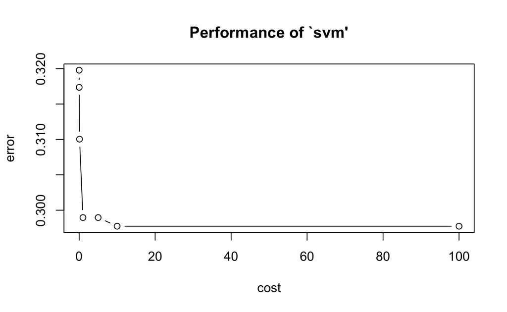

```r
plot(mental_health_poly_tune)
```

# Part 3: OJ Simpson

## 1. What is the relationship between race and belief of OJ Simpson’s guilt? Develop a robust statistical learning model and use this model to explain the impact of an individual’s race on their beliefs about OJ Simpson’s guilt.

For this question, logistic model seems intuitive and appropriate because `guilt` is a binary variable.

```r
set.seed(1234)

getProb <- function(model, data){
  data <- data %>%
    add_predictions(model) %>%
    mutate(prob = exp(pred) / (1 + exp(pred)),
           pred_bi = as.numeric(prob > .5))
  return(data)
}

simpson_split <- resample_partition(simpson, c(test = 0.3, train = 0.7))

model_logistic <- glm(guilt ~ black + hispanic, data = simpson_split$train, family = binomial)
summary(model_logistic)
```

```
##
## Call:
## glm(formula = guilt ~ black + hispanic, family = binomial, data = simpson_split$train)
##
## Deviance Residuals:
##    Min      1Q  Median      3Q     Max
## -1.826  -0.608   0.647   0.647   2.119
##
## Coefficients:
##             Estimate Std. Error z value Pr(>|z|)
## (Intercept)   1.4587     0.0938   15.55   <2e-16 ***
## black1       -3.0529     0.2169  -14.07   <2e-16 ***
## hispanic1    -0.5388     0.2846   -1.89    0.058 .
## ---
## Signif. codes:  0 '***' 0.001 '**' 0.01 '*' 0.05 '.' 0.1 ' ' 1
##
## (Dispersion parameter for binomial family taken to be 1)
##
##     Null deviance: 1233.12  on 986  degrees of freedom
## Residual deviance:  956.83  on 984  degrees of freedom
##   (112 observations deleted due to missingness)
## AIC: 962.8
##
## Number of Fisher Scoring iterations: 4
```

```r
df_logistic_test <- getProb(model_logistic, as.data.frame(simpson_split$test))

auc_x <- auc(df_logistic_test$guilt, df_logistic_test$pred_bi)
auc_x
```

```
## Area under the curve: 0.744
```

```r
accuracy <- mean(df_logistic_test$guilt == df_logistic_test$pred_bi, na.rm = TRUE)
accuracy
```

```
## [1] 0.83
```

```r
real <- na.omit(as.numeric(as_tibble(simpson_split$test)$guilt))
E1 <- mean(as.numeric(real != median(real)))
E2 <- 1 - accuracy
PRE <- (E1 - E2) / E1
PRE
```

```
## [1] 0.434
```

The logistic model have a 0.83 accuracy, a 0.434 PRE and a 0.744 AUC, which is acceptable.

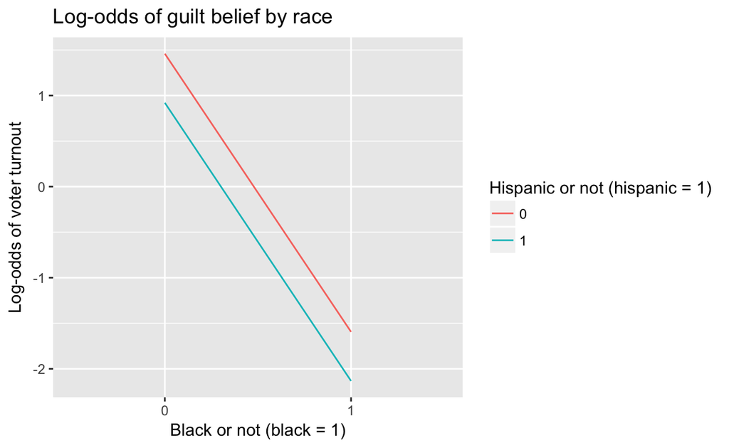

```r
logistic_grid <- as.data.frame(simpson_split$test) %>%
  data_grid(black, hispanic) %>%
  add_predictions(model_logistic) %>%
  mutate(prob = exp(pred) / (1 + exp(pred)))

ggplot(logistic_grid, aes(black, pred, group = factor(hispanic), color = factor(hispanic))) +
  geom_line() +
  scale_color_discrete(name = "Hispanic or not (hispanic = 1)") +
  labs(title = "Log-odds of guilt belief by race",
       x = "Black or not (black = 1)",
       y = "Log-odds of voter turnout")
```

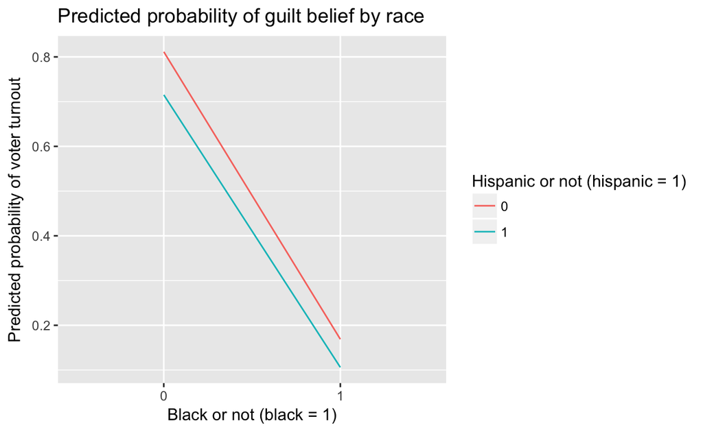

```r
ggplot(logistic_grid, aes(black, prob, group = factor(hispanic), color = factor(hispanic))) +
  geom_line() +
  scale_color_discrete(name = "Hispanic or not (hispanic = 1)") +
  labs(title = "Predicted probability of guilt belief by race",
       x = "Black or not (black = 1)",
       y = "Predicted probability of voter turnout")
```

## 2. How can you predict whether individuals believe OJ Simpson to be guilty of these murders? Develop a robust statistical learning model to predict whether individuals believe OJ Simpson to be either probably guilty or probably not guilty and demonstrate the effectiveness of this model using methods we have discussed in class.

For the prediction part a tree-based model would be reasonable, since it’s intuitive to divide the observations into different regions to support prediction. Therefore, I would like to apply Random Forest model on this dataset.

```r
set.seed(1234)

simpson_rf <- randomForest(guilt ~ dem + rep + age + educ + female + black + hispanic + income, data = na.omit(as_tibble(simpson_split$train)))
simpson_rf
```

```
##
## Call:
##  randomForest(formula = guilt ~ dem + rep + age + educ + female +      black + hispanic + income, data = na.omit(as_tibble(simpson_split$train)))
##                Type of random forest: classification
##                      Number of trees: 500
## No. of variables tried at each split: 2
##
##         OOB estimate of  error rate: 19.4%
## Confusion matrix:
##     0   1 class.error
## 0 157 156      0.4984
## 1  35 639      0.0519
```

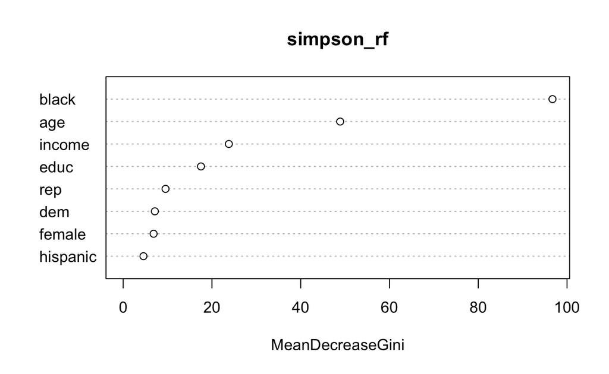

```r
varImpPlot(simpson_rf)
```

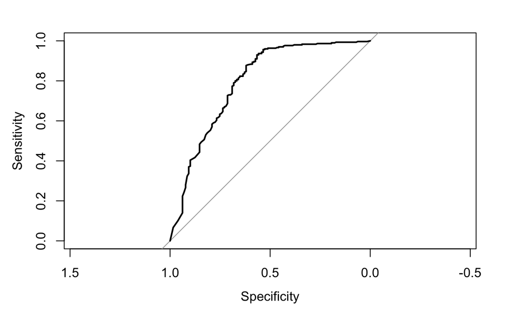

```r
fitted <- predict(simpson_rf, na.omit(as_tibble(simpson_split$test)), type = "prob")[,2]

roc_rf <- roc(na.omit(as_tibble(simpson_split$test))$guilt, fitted)
plot(roc_rf)
```

```r
auc(roc_rf)
```

```
## Area under the curve: 0.795
```

```r
real <- na.omit(as.numeric(as_tibble(simpson_split$test)$guilt))
E1 <- mean(as.numeric(real != median(real)))
E2 <- 0.1935
PRE <- (E1 - E2) / E1
PRE
```

```
## [1] 0.356
```

The Random Forest model gives us a 0.356 PRE and 0.795 AUC, which is acceptable.

Also, black indicator, age, and income seem to be the top 3 important predictors. The black indicator is in the first place, which is aligned with the conclusion from the previous analysis.